# final

Importing necessary libraries

```python
# 1. `pandas`: Used for data manipulation and analysis. It provides convenient data structures and functions to work with structured data,
# such as DataFrames, which can be useful for organizing and preprocessing textual data before topic modeling.

# 2. `re`: It is used for pattern matching and text manipulation tasks, such as removing URLs or special characters.

# 3. `gensim`: It provides functions from `gensim` for building the LDA model, preprocessing text, and calculating topic coherence.

# 4. `corpora` (from `gensim`): offers functionality for creating, loading, and saving document collections in different formats.

# 5. `simple_preprocess` (from `gensim.utils`): for performing simple preprocessing tasks such as lowercasing, tokenizing, and removing stopwords.

# 6. `CoherenceModel` (from `gensim.models`): A class in `gensim` for computing topic coherence scores.

# 7. `spacy`: It provides tools and models for part-of-speech tagging, entity recognition, and lemmatization.

# 8. `matplotlib.pyplot` (imported as `plt`): In topic modeling, it can be used to visualize the results,
# such as topic-word distributions or coherence scores.

# 9. `WordCloud` (from `wordcloud`): A library for generating word clouds, which visually represent the
# most frequent words in a text corpus. It is often used to visualize the most important terms associated with each topic in topic modeling.

# 10. `stopwords` (from `nltk.corpus`): These are words that are considered insignificant
# in the context of text analysis, such as "and," "the," or "is."

import pandas as pd
import re
import gensim
import gensim.corpora as corpora
from gensim.utils import simple_preprocess
from gensim.models import CoherenceModel
import spacy
import matplotlib.pyplot as plt
from wordcloud import WordCloud
from nltk.corpus import stopwords
# Plotting tools
import pyLDAvis
import pyLDAvis.gensim  # don't skip this
import matplotlib.pyplot as plt
%matplotlib inline
```

Loading Dataset - can be found in the link- [amazon reviews (press here)](https://www.kaggle.com/datasets/kritanjalijain/amazon-reviews), used train.csv file for this project

```python
# Load the dataset - 28sec
df = pd.read_csv(r'D:\Education\University\Multi Modal Data Analysis\Project\Dataset samples\amazon_review_polarity_csv\train.csv')
```

considered only 1,00,000 rows of data

```python
df_new = df.head(100000)
df_new.columns = ['Sentiment Score', 'Head', 'Body']
```

```python
df_new
```

|  | Sentiment Score | Head | Body |
| --- | --- | --- | --- |
| 0 | 2 | The best soundtrack ever to anything. | I'm reading a lot of reviews saying that this ... |
| 1 | 2 | Amazing! | This soundtrack is my favorite music of all ti... |
| 2 | 2 | Excellent Soundtrack | I truly like this soundtrack and I enjoy video... |
| 3 | 2 | Remember, Pull Your Jaw Off The Floor After He... | If you've played the game, you know how divine... |
| 4 | 2 | an absolute masterpiece | I am quite sure any of you actually taking the... |
| ... | ... | ... | ... |
| 99995 | 1 | THE REAL SUPERMAN | THESE ARE THE REAL ADVENTURES OF THE REAL SUPE... |
| 99996 | 1 | It gets one star because zero was not an optio... | Sylvain Beauregard is WIDELY known to die-hard... |
| 99997 | 1 | Don't Spend Your Money | I think I now know more about the person who w... |
| 99998 | 1 | Enough already | This is what you call "overkill." How many boo... |
| 99999 | 2 | Great book for the collectors | Hi I think this is a great book for the collec... |

100000 rows × 3 columns

Considering only body column of the data

```python
# Preprocess the data
data = df_new.Body.values.tolist()
data = [re.sub('\S*@\S*\s?', '', sent) for sent in data]
data = [re.sub('\s+', ' ', sent) for sent in data]
data = [re.sub("'", '', sent) for sent in data]
```

```python
# Remove stopwords - 21sec for 1lakh
stop_words = stopwords.words('english')
def remove_stopwords(texts):
    return [[word for word in simple_preprocess(str(doc)) if word not in stop_words] for doc in texts]

data_words = remove_stopwords(data)
```

Tokenization

```python
# Tokenization - 14sec for 1 lakh
def sent_to_words(sentences):
    for sentence in sentences:
        yield(gensim.utils.simple_preprocess(str(sentence), deacc=True))

data_words = list(sent_to_words(data_words))
```

Bigrams and Trigrams

```python
# Build bigram and trigram models - 17sec for 1 lakh
bigram = gensim.models.Phrases(data_words, min_count=5, threshold=100)
trigram = gensim.models.Phrases(bigram[data_words], threshold=100)
bigram_mod = gensim.models.phrases.Phraser(bigram)
trigram_mod = gensim.models.phrases.Phraser(trigram)
```

```python
# Form Bigrams
data_words_bigrams = [bigram_mod[doc] for doc in data_words]
data_words_trigrams = [trigram_mod[bigram_mod[doc]] for doc in data_words_bigrams]
```

Lemmatization

```python
# Lemmatization - 10m for 1 lakh
nlp = spacy.load('en_core_web_sm')
def lemmatization(texts, allowed_postags=['NOUN', 'ADJ', 'VERB', 'ADV']):
    texts_out = []
    for sent in texts:
        doc = nlp(" ".join(sent))
        texts_out.append([token.lemma_ for token in doc if token.pos_ in allowed_postags])
    return texts_out

data_lemmatized = lemmatization(data_words_trigrams, allowed_postags=['NOUN', 'ADJ', 'VERB', 'ADV'])
```

Word Cloud

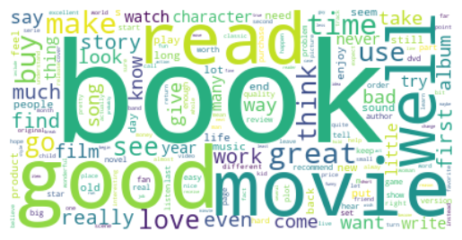

```python
# Generate and display a word cloud
word_list = [word for sublist in data_lemmatized for word in sublist]
text = ' '.join(word_list)
word_cloud2 = WordCloud(collocations=False, background_color='white').generate(text)
plt.imshow(word_cloud2, interpolation='bilinear')
plt.axis("off")
plt.show()
```

creating a dictionary to map tokens to unique IDs and creating a corpus in the bag-of-words format, which is a numerical representation of the documents that can be used as input for LDA model.

```python
# Create dictionary and corpus
id2word = corpora.Dictionary(data_lemmatized)
texts = data_lemmatized
corpus = [id2word.doc2bow(text) for text in texts]
```

LDA model building

```python
# Build LDA model - 150min. 1lakh, 100 rs, cs 50, pass 100,
lda_model = gensim.models.ldamodel.LdaModel(corpus=corpus,
                                           id2word=id2word,
                                           num_topics=8,
                                           random_state=100,
                                           update_every=1,
                                           chunksize=50, # prev 100
                                           passes=100,  # prev 10
                                           alpha='auto',
                                           per_word_topics=True)

#chunksize controls how many documents are processed at a time in the training algorithm.
#Increasing chunksize will speed up training, at least as long as the chunk of documents easily fit into memory.
#passes controls how often we train the model on the entire corpus (set to 10).
#Another word for passes might be “epochs”.
#Iterations is somewhat technical, but essentially it controls how often we repeat a particular loop over each document.
#It is important to set the number of “passes” and “iterations” high enough.

# Print the topics
from pprint import pprint
pprint(lda_model.print_topics())

# Further analysis of the topics as needed
doc_lda = lda_model[corpus]
```

```
[(0,
  '0.078*"product" + 0.051*"purchase" + 0.037*"order" + 0.028*"month" + '
  '0.022*"receive" + 0.021*"week" + 0.020*"send" + 0.019*"wrong" + '
  '0.019*"card" + 0.014*"shoe"'),
 (1,
  '0.041*"song" + 0.040*"album" + 0.030*"music" + 0.028*"sound" + 0.022*"hear" '
  '+ 0.019*"fan" + 0.018*"version" + 0.018*"listen" + 0.015*"track" + '
  '0.014*"favorite"'),
 (2,
  '0.050*"bad" + 0.038*"people" + 0.036*"ever" + 0.032*"s" + 0.025*"star" + '
  '0.024*"part" + 0.024*"live" + 0.015*"job" + 0.015*"copy" + 0.014*"full"'),
 (3,
  '0.029*"learn" + 0.026*"series" + 0.026*"style" + 0.021*"stuff" + '
  '0.020*"piece" + 0.019*"rather" + 0.018*"name" + 0.017*"person" + '
  '0.016*"collection" + 0.016*"description"'),
 (4,
  '0.034*"buy" + 0.033*"use" + 0.032*"well" + 0.032*"work" + 0.019*"look" + '
  '0.017*"try" + 0.016*"come" + 0.016*"many" + 0.015*"need" + 0.013*"put"'),
 (5,
  '0.089*"book" + 0.042*"read" + 0.018*"find" + 0.018*"story" + 0.014*"write" '
  '+ 0.014*"character" + 0.011*"end" + 0.009*"author" + 0.009*"life" + '
  '0.009*"well"'),
 (6,
  '0.043*"good" + 0.036*"get" + 0.031*"great" + 0.030*"time" + 0.030*"make" + '
  '0.024*"movie" + 0.022*"go" + 0.021*"love" + 0.020*"think" + 0.020*"really"'),
 (7,
  '0.036*"drive" + 0.036*"film" + 0.026*"man" + 0.026*"real" + 0.022*"big" + '
  '0.016*"woman" + 0.016*"early" + 0.015*"fit" + 0.015*"else" + 0.013*"case"')]
```

we can estimate from the above topics that  
topic 0 refers to Consumer goods,  
topic 1 refers to music,  
topic 2 refers to Negative experience,  
topic 3 refers to Miscellanious,  
topic 4 refers to General usage,  
topic 5 refers to Literature,  
topic 6 refers to Positive Experience,  
topic 7 refers to Entertainment.

Identifying Dominant Topics

```
Topic 6: 44625 documents
Topic 5: 36710 documents
Topic 4: 16702 documents
Topic 1: 1782 documents
Topic 0: 122 documents
Topic 7: 34 documents
Topic 2: 20 documents
Topic 3: 5 documents
```

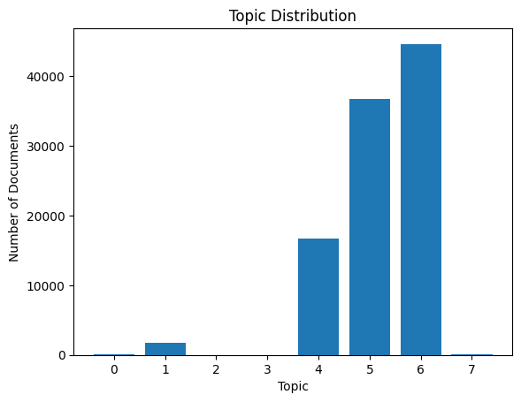

```python
doc_lda = [lda_model.get_document_topics(doc) for doc in corpus]
# Identify dominant topics
dominant_topics = [max(topic, key=lambda item: item[1])[0] for topic in doc_lda]

# Count the occurrences of each dominant topic
topic_counts = {topic: dominant_topics.count(topic) for topic in dominant_topics}

# Sort the topics based on their counts in descending order
sorted_topics = sorted(topic_counts.items(), key=lambda item: item[1], reverse=True)

# Print the dominant topics and their counts
for topic, count in sorted_topics:
    print(f"Topic {topic}: {count} documents")

# Visualize topic distribution
topics, counts = zip(*sorted_topics)

plt.bar(topics, counts)
plt.xlabel('Topic')
plt.ylabel('Number of Documents')
plt.title('Topic Distribution')
plt.show()
```

The above output prints topic number and number of documents it is dominated in. Below we will choose a topic and print out the documents in which the topic is dominant.

```python
# Choose a topic
chosen_topic = 2  # Change this value to the index of the desired topic

total = 0
# Print documents belonging to the chosen topic
for index, document in enumerate(data_lemmatized):
    doc_topics = lda_model.get_document_topics(corpus[index])
    dominant_topic = max(doc_topics, key=lambda item: item[1])[0]

    if dominant_topic == chosen_topic:
        #print(f"Document {index + 1}: {document}")
        # print(f"Document {index + 1}: ")
        # print(data[index])
        print(f"Document {index + 1}: {data[index]}")
        total = total + 1

print("total = " + str(total))
```

```
Document 22: Rather than scratches and insect droppings, this one has random pixelations combined with muddy light and vague image resolution. Probably the cue should have been the packaging is straight out of your street corner bootleg dealer.If youve ever seen a reasonably good condition film copy…
Document 1356: This is one of the worst Cds Ive ever heard. This chick is garbage and sos this cd. Dont waste your money on this one. Chopper Girl...haha....more like wack as hell girl. I didnt even wanna give you one star but I had to.
Document 7693: nothing but chugga chugga beats, and exteremly repeative breakdowns and boring vocals , the worst of the worst when it comes to H.C. .
Document 7720: There is no close caption to the movie, and it is very boring, due to not understanding what is going on without close caption. Remeber there are 21 million deaf and/or hard of hearing people in U.S.A. that depends on close caption. If ypu cut our close caption off, then the rating fa…
Document 10102: rotten to the core , rotten to the core , rotten to the core and oh yes, did i say ROTTEN TO THE CORE !!!!
Document 21548: Simply awesome. Had me pumping my fist in the air and yelling, "Yes!" over and over again. I read this in one marthon session of fist-pumping and yelling.
Document 24483: Terry Farrell, Rick Springfield, Parker Stevenson, Corey Feldman are the "headline" actors in this flat and slow moving Sci-Fi Channel exclusive. None of them are directed to their potential in this excuse of an "Aliens" wannabe. Poor storyline also contributes. Only buy this if you …
Document 26032: If you are at all familiar with Joyces "Ulysses" then you will be more than pleased with this presentation. The explanation concerning the difficulty in preparing it for this oral reading is an excellent aid for the "listener" in further understanding this masterpiece.If you are not …
Document 31583: This is probably the worst panasonic phone ever. Thebattery life is a joke. You charged the phone for wholeday, and after 1 hour talking, you have to recharge itagain. Completely useless.This will be the last panasonic phone I will ever buy
Document 32264: Somehow I had the impression that the phone had a "Message Waiting" LED indicator. But what they dont tell you is that the same LED is used to indicate "missed calls" - which to me makes the LED totally worthless. The phone I had before used the same light, but it flashed green for m…
Document 50438: This game is one of the worst games I have ever played. I got it on clearance for $...and I still felt like I had paid too much. This is NOT comparible to Star Fox for the SNES. If it was, this would be one of the biggest titles for the GBA. For a shooter, the aim is one of the worst…
Document 56933: The cartridges are not recognized by the printer as being full of ink so the annoying "low ink" indicator comes up everytime you print. I wouldnt say that it outweighs the savings, however it is annoying. As advanced as technology is these days there should be someone who can "reset"…
Document 65200: Ever since a certain Berkley trio unleashed the petulant lyric "listen to me whine", theres been no end of bands queuing up to unburden their litany of woes. Canuck five-piece Simple Plan are one such outfit, quick to illustrate that they too can moan about how life is so damn unfair…
Document 69782: Inane, do not waste your time, pure garbage.Inane, do not waste your time, pure garbage.Inane, do not waste your time, pure garbage.Inane, do not waste your time, pure garbage.Inane, do not waste your time, pure garbage.Inane, do not waste your time, pure garbage.Inane, do not waste …
Document 71364: Three stars???? Proof once again of peoples low standards and Hollywoods ability to shove steaming crap into the publics mouths and have them swallow happily.Another on my list of Top Ten Worst Movies Ive Ever Seen.
Document 76327: Thats all this dvd was good for, toilet paper. Just a bad bad movie. I gave it a shot because it was new, and now I wish I had saved that shot for my head. Bad acting, bad plot, bad acting, bad special effects, bad audio dubbing, bad acting, bad characters, and did I mention bad acti…
Document 77475: This is a very strange CD. The label is basically unknown to most people. Worse than that, there is no conductor or orchestra named. However, the performances are excellent, some of the finest Mozart symphony performances you will ever hear. The playing is warm and spontaneous. There…
Document 82672: Tight Cd,Dont have much to say,still sad shes gone =(,but heres how I rate her songs...1.We need a resolution-5 stars2.Loose Rap-2 stars-3.Rock the boat-4 1/2 stars4.More than a women-5 stars5.Never no more-5 stars6.I care 4 u-5 stars7.Extra smooth-4 1/2 stars8.Read between the lines…
Document 94156: One of the worst albums of all time. Bad bad bad bad. Marilyn Manson has sold out, and this album proves it. Bad lyrics. Bad music. Bad bad bad.Buy AntiChrist Superstar instead, Holywood:In The Shadow of The Valley of death, or Smells Like Children. Just dont buy The Golden Age of Gr…
Document 97375: About the worst transfer ever! Video is horribly bad, seems like it was taped from a T.V. with snowy reception. Dont waste your money. Bad, bad, bad!!!
total = 20
```

Topic 2 is chosen and it is dominant in 20 dcouments. All the 20 documents are printed above with total count at the end.

```python
# Compute Perplexity
print('\nPerplexity: ', lda_model.log_perplexity(corpus))  # a measure of how good the model is. lower the better.

# Compute Coherence Score
coherence_model_lda = CoherenceModel(model=lda_model, texts=data_lemmatized, dictionary=id2word, coherence='c_v')
coherence_lda = coherence_model_lda.get_coherence()
print('\nCoherence Score: ', coherence_lda)
```

```
Perplexity:  -8.43120893241583

Coherence Score:  0.46693764308248253
```

```python
# Visualize the topics
pyLDAvis.enable_notebook()
vis = pyLDAvis.gensim.prepare(lda_model, corpus, id2word)
```

Visualization using pyLDAvis

```python
vis
```

[interactive chart not shown]